# papaja: Prepare APA Journal Articles with R Markdown

[figure not shown]

[figure not shown]

**papaja** is an [award-winning](https://improvingpsych.org/mission/awards/) R package that facilitates creating computationally reproducible, submission-ready manuscripts which conform to the American Psychological Association (APA) manuscript guidelines (6th Edition). **papaja** provides

- an [R Markdown](http://rmarkdown.rstudio.com/) template that can be used with (or without) [RStudio](http://www.rstudio.com/) to create PDF documents (using the apa6 LaTeX class) or Word documents (using a .docx-reference file).
- Functions to **typeset** the results from **statistical analyses**,
- functions to create **tables**, and
- functions to create **figures** in accordance with APA guidelines.

For a comprehensive introduction to **papaja**, see the current draft of the [manual](https://crsh.github.io/papaja_man/). If you have a specific question that is not answered in the manual, feel free to ask a question on Stack Overflow [using the **papaja** tag](https://t.co/Z3auyUrbTa). If you believe you have found a bug or would like to request a new feature, [open an issue](https://github.com/crsh/papaja/issues) on Github and provide a [minimal complete verifiable example](https://stackoverflow.com/help/mcve).

## Example

Take a look at the [R Markdown file](https://github.com/crsh/papaja/blob/master/inst/example/example.rmd) of the example manuscript in the folder `example` and the resulting [PDF](https://raw.githubusercontent.com/crsh/papaja/master/inst/example/example.pdf). The example document also contains some basic instructions.

## Installation

To use **papaja** you need either a recent version of [RStudio](http://www.rstudio.com/) or [pandoc](http://johnmacfarlane.net/pandoc/). If you want to create PDF- in addition to DOCX-documents you additionally need a TeX distribution. We recommend you use [TinyTex](https://yihui.name/tinytex/), which can be installed from within R:

```r
if(!requireNamespace("tinytex", quietly = TRUE)) install.packages("tinytex")

tinytex::install_tinytex()
```

You may also consider [MikTeX](http://miktex.org/) for Windows, [MacTeX](https://tug.org/mactex/) for Mac, or [TeX Live](http://www.tug.org/texlive/) for Linux. Please refer to the [**papaja** manual](https://crsh.github.io/papaja_man/introduction.html#getting-started) for detailed installation instructions.

**papaja** is not yet available on CRAN but you can install it from this repository:

```r
# Install remotes package if necessary
if(!requireNamespace("remotes", quietly = TRUE)) install.packages("remotes")

# Install the stable development version from GitHub
remotes::install_github("crsh/papaja")

# Install the latest development snapshot from GitHub
remotes::install_github("crsh/papaja@devel")
```

## Usage

Once **papaja** is installed, you can select the APA template when creating a new R Markdown file through the RStudio menus.

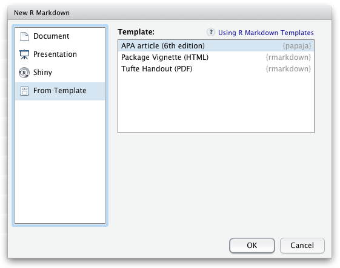

To add citations, specify your bibliography-file in the YAML front matter of the document (`bibliography: my.bib`) and start citing (for details, see pandoc manual on the [citeproc extension](https://pandoc.org/MANUAL.html#extension-citations). You may also be interested in [**citr**](https://github.com/crsh/citr), an R Studio addin to swiftly insert Markdown citations and [R Studio’s visual editor](https://rstudio.github.io/visual-markdown-editing/), which also enables swiftly [inserting citations](https://rstudio.github.io/visual-markdown-editing/citations.html).

### Typeset analysis results

The functions `apa_print()` and `apa_table()` facilitate reporting results of your analyses. When you pass the an output object of a supported class, such as an `htest`- or `lm`-object, to `apa_print()`, it will return a list of character strings that you can use to report the results of your analysis.

```r
my_lm <- lm(
  Sepal.Width ~ Sepal.Length + Petal.Width + Petal.Length
  , data = iris
)
apa_lm <- apa_print(my_lm)

apa_lm$full_result$Sepal_Length
```

```
## [1] "$b = 0.61$, 95\\% CI $[0.48, 0.73]$, $t(146) = 9.77$, $p < .001$"
```

**papaja** currently provides methods for the following object classes:

| A-B | D-L | L-S | S-Z |
| --- | --- | --- | --- |
| afex_aov | default | lsmobj | summary.aovlist |
| anova | emmGrid | manova | summary.glht* |
| anova.lme | glht* | merMod | summary.glm |
| Anova.mlm | glm | mixed | summary.lm |
| aov | htest | papaja_wsci | summary.manova |
| aovlist | list | summary_emm | summary.ref.grid |
| BFBayesFactor* | lm | summary.Anova.mlm |  |
| BFBayesFactorTop* | lme | summary.aov |  |

* Not fully tested, don’t trust blindly!

### Create tables

`apa_table()` may be used to produce publication-ready tables in an R Markdown document. For instance, you might want to report some condition means (with standard errors).

```r
library("dplyr")
npk |>
  group_by(N, P) |>
  summarise(mean = mean(yield), se = se(yield), .groups = "drop") |>
  label_variables(N = "Nitrogen", P = "Phosphate", mean = "*M*", se = "*SE*") |>
  apa_table(caption = "Mean pea yield (with standard errors)")
```

Table 1. *Mean pea yield (with standard errors)*

| Nitrogen | Phosphate | *M* | *SE* |
| --- | --- | --- | --- |
| 0 | 0 | 51.72 | 1.88 |
| 0 | 1 | 52.42 | 2.65 |
| 1 | 0 | 59.22 | 2.66 |
| 1 | 1 | 56.15 | 2.08 |

This is a fairly simple example, but `apa_table()` may be used to generate [more complex tables](https://osf.io/s4968/).

`apa_table()`, of course, plays nicely with the output from `apa_print()`. Thus, it is possible to conveniently report complete regression tables, ANOVA tables, or the output from mixed-effects models.

```r
lm(Sepal.Width ~ Sepal.Length + Petal.Width + Petal.Length, data = iris) |>
  apa_print() |>
  apa_table(caption = "Iris regression table.")
```

Table 2. *Iris regression table.*

| Predictor | *b* | 95% CI | *t* | *d**f* | *p* |
| --- | --- | --- | --- | --- | --- |
| Intercept | 1.04 | [0.51, 1.58] | 3.85 | 146 | < .001 |
| Sepal Length | 0.61 | [0.48, 0.73] | 9.77 | 146 | < .001 |
| Petal Width | 0.56 | [0.32, 0.80] | 4.55 | 146 | < .001 |
| Petal Length | -0.59 | [-0.71, -0.46] | -9.43 | 146 | < .001 |

### Create figures

**papaja** further provides functions to create publication-ready plots. For example, you can use `apa_barplot()`, `apa_lineplot()`, and `apa_beeplot()` (or the general function `apa_factorial_plot()`) to visualize the results of factorial study designs:

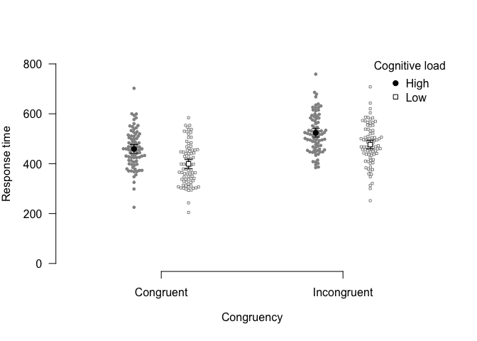

```r
apa_beeplot(
  data = stroop_data
  , dv = "response_time"
  , id = "id"
  , factors = c("congruency", "load")
  , ylim = c(0, 800)
  , dispersion = wsci # within-subjects confidence intervals
  , conf.level = .99
  , las = 1
)
```

If you prefer creating your plots with `ggplot2`, try `theme_apa()`.

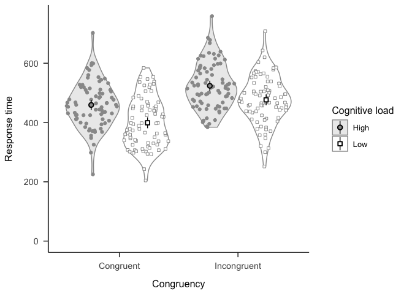

```r
library("ggplot2")
library("ggforce")

p <- ggplot(
  stroop_data
  , aes(x = congruency, y = response_time, shape = load, fill = load)
) +
  geom_violin(alpha = 0.2, color = grey(0.6)) +
  geom_sina(color = grey(0.6)) +
  stat_summary(position = position_dodge2(0.95), fun.data = mean_cl_normal) +
  lims(y = c(0, max(stroop_data$response_time))) +
  scale_shape_manual(values = c(21, 22)) +
  scale_fill_grey(start = 0.6, end = 1) +
  labs(
    x = "Congruency"
    , y = "Response time"
    , shape = "Cognitive load"
    , fill = "Cognitive load"
  )

p + theme_apa()
```

### Usage without RStudio

Don’t use RStudio? No problem. Use the `rmarkdown::render` function to create articles:

```r
# Create new R Markdown file
rmarkdown::draft(
  "mymanuscript.Rmd"
  , "apa6"
  , package = "papaja"
  , create_dir = FALSE
  , edit = FALSE
)

# Render manuscript
rmarkdown::render("mymanuscript.Rmd")
```

## Getting help

[figure not shown]

For a comprehensive introduction to **papaja**, check out the current draft of the [**papaja** manual](https://crsh.github.io/papaja_man/). If you have a specific question that is not answered in the manual, feel free to ask a question on Stack Overflow [using the **papaja** tag](https://t.co/Z3auyUrbTa). If you believe you have found a bug or you want to request a new feature, [open an issue](https://github.com/crsh/papaja/issues) on Github and provide a [minimal complete verifiable example](https://stackoverflow.com/help/mcve).

## Citation

Please cite **papaja** if you use it. You can for example [use `cite_r()`](https://crsh.github.io/papaja_man/writing.html#citing-r-and-its-packages) or copy the reference information returned by `citation('papaja')` to your BibTeX file.

```
Aust, F. & Barth, M. (2020). papaja: Prepare reproducible APA journal articles with R Markdown. R package version 0.1.0.9997. Retrieved from https://github.com/crsh/papaja
```

## papaja in the wild

If you are interested to see how others are using **papaja**, you can find a [collection of papers](http://frederikaust.com/papaja_man/published-manuscripts.html) and the corresponding R Markdown files in the manual.

If you have published a paper that was written with **papaja**, please add the reference to the [public Zotero group](https://www.zotero.org/groups/2202906/papaja) yourself or send us to me.

## Computational reproducibility

To ensure mid- to long-term computational reproducibility we highly recommend conserving the software environment used to write a manuscript (e.g. R and all R packages) either in a software container or a virtual machine. This way you can be sure that your R code does not break because of updates to R or any R package. For a brief primer on containers and virtual machines see [the supplementary material](https://psych-transparency-guide.uni-koeln.de/analytic-reproducibility.html#document-hardware-and-software-used-for-analyses) by Klein et al. (2018).

[Docker](https://www.docker.com/) is the most widely used containerization approach. It is open source and free to use but requires some disk space. [CodeOcean](https://codeocean.com/) is a commercial service that builds on Docker, facilitates setting up and sharing containers and lets you run computations in the cloud. See the **papaja** manual on [how to get started using **papaja** with Docker or CodeOcean](https://crsh.github.io/papaja_man/tips-and-tricks.html#reproducible-software-environments) and [our Docker workflow](https://github.com/crsh/papaja_docker) tailored for easy use with **papaja**.

## Contribute

[figure not shown]

Like **papaja** and want to contribute? We highly appreciate any contributions to the R package or its documentation. Take a look at the [open issues](https://github.com/crsh/papaja/issues) if you need inspiration. There are many additional analyses that we would like `apa_print()` to support. Any new S3/S4-methods for this function are always appreciated (e.g., `factanal`, `fa`, `lavaan`). For a primer on adding new `apa_print()`-methods, see the getting-started-vignette:

```r
`vignette("add_apa_print_methods", package = "papaja")`
```

Before working on a contribution, please review our brief [contributing guidelines](https://github.com/crsh/papaja/blob/master/.github/CONTRIBUTING.md) and [code of conduct](https://github.com/crsh/papaja/blob/master/CODE_OF_CONDUCT.md).

## Related R packages

By now, there are a couple of R packages that provide convenience functions to facilitate the reporting of statistics in accordance with APA guidelines.

- [**apa**](https://github.com/dgromer/apa): Format output of statistical tests in R according to APA guidelines
- [**APAstats**](https://github.com/achetverikov/APAstats): R functions for formatting results in APA style and other stuff
- [**apaTables**](https://github.com/dstanley4/apaTables): Create American Psychological Association (APA) Style Tables
- [**rempsyc**](https://github.com/RemPsyc/rempsyc): Convenience functions for psychology
- [**sigr**](https://github.com/WinVector/sigr): Concise formatting of significances in R

If you are looking for other journal article templates, you may be interested in the [**rticles**](https://github.com/rstudio/rticles) package.

## Package dependencies

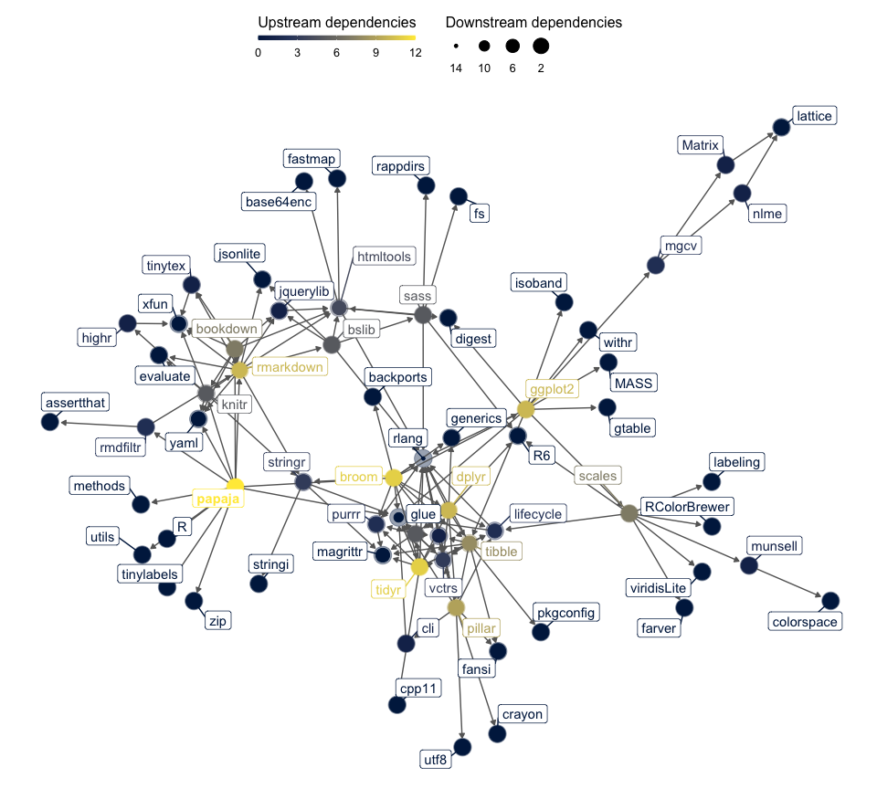